```r
# install `pacman` if necessary.
if (!require("pacman")) install.packages("pacman")
```

```r
# load, install packages via `pacman`
pacman::p_load(
  tidycensus,    # census api
  tidyverse,     # data wrangling & tables
  janitor,
  sf,            # spatial stuff
  leaflet,
  mapview
)

options(tigris_use_cache = TRUE)
```

- You need a `Census API key` to access Census Bureau API

https://api.census.gov/data/key_signup.html

- Key will be sent to your email fairly quickly

Info for all public facing Census API: https://www.census.gov/data/developers/data-sets.html*

Uncomment and run chunk below to store Census key locally.

```r
# census_api_key("YOuR CENSUS API KEY HERE",
#              install = TRUE)
#  store locally
# census_api_key(key = my_census_api_key)
```

- Load variables available from Census Bureau API
- Info explaining each value in the `dataset` argument. https://api.census.gov/data.html

```r
acs_2019_vars <- load_variables(2019,   # year
                 dataset = 'acs1',      # specify `acs1` data
                  cache = T) %>%        # save call locally
  # tab out results as window
  View()
```

- There’s lots of variables here! Below we slice out relevant population counts for sex, age, and race.

```r
acs2019_slice <- load_variables(2019, # relevant variable names.
                  dataset = 'acs1',
                  cache = T) %>%
                 slice(1:328) #subset top 328 rows
```

- Create Object with those `328` variables, spaced in a friendly way to add to a `get_acs()` call to the API.

```r
acs_vars <-
  # add white-space on both sides.
  str_pad(acs2019_slice$name, 1,
          side = 'both',
          pad = ' ')
head(acs_vars)
```

```
## [1] "B01001_001" "B01001_002" "B01001_003" "B01001_004" "B01001_005"
## [6] "B01001_006"
```

With a little clever text-editing (hold *Ctrl* key to select tabular-ly and dragging around) we can create a concatenated list of all variables.

```r
# All "population" variables by sex and race? 2019 ACS
all_those_vars = c(
  "B01001_001" ,"B01001_002" ,"B01001_003" ,
  "B01001_004" ,"B01001_005" ,"B01001_006" ,
  "B01001_007" ,"B01001_008"  ,"B01001_009" ,
  "B01001_010" ,"B01001_011" ,"B01001_012" ,
  "B01001_013" ,"B01001_014" ,"B01001_015" ,
  "B01001_016" ,"B01001_017" ,"B01001_018" ,
  "B01001_019" ,"B01001_020" ,"B01001_021" ,
  "B01001_022" ,"B01001_023" ,"B01001_024" ,
  "B01001_025" ,"B01001_026" ,"B01001_027" ,
  "B01001_028" ,"B01001_029" ,"B01001_030" ,
  "B01001_031" ,"B01001_032" ,"B01001_033" ,
  "B01001_034" ,"B01001_035" ,"B01001_036" ,
  "B01001_037" ,"B01001_038" ,"B01001_039" ,
  "B01001_040" ,"B01001_041" ,"B01001_042" ,
  "B01001_043" ,"B01001_044" ,"B01001_045" ,
  "B01001_046" ,"B01001_047" ,"B01001_048" ,
  "B01001_049" ,"B01001A_001","B01001A_002",
  "B01001A_003","B01001A_004","B01001A_005",
  "B01001A_006","B01001A_007","B01001A_008",
  "B01001A_009","B01001A_010","B01001A_011",
  "B01001A_012","B01001A_013","B01001A_014",
  "B01001A_015","B01001A_016","B01001A_017",
  "B01001A_018","B01001A_019","B01001A_020",
  "B01001A_021","B01001A_022","B01001A_023",
  "B01001A_024","B01001A_025","B01001A_026",
  "B01001A_027","B01001A_028","B01001A_029",
  "B01001A_030","B01001A_031","B01001B_001",
  "B01001B_002","B01001B_003","B01001B_004",
  "B01001B_005","B01001B_006","B01001B_007",
  "B01001B_008","B01001B_009","B01001B_010",
  "B01001B_011","B01001B_012","B01001B_013",
  "B01001B_014","B01001B_015","B01001B_016",
  "B01001B_017","B01001B_018","B01001B_019",
  "B01001B_020","B01001B_021","B01001B_022",
  "B01001B_023","B01001B_024","B01001B_025",
  "B01001B_026","B01001B_027","B01001B_028",
  "B01001B_029","B01001B_030","B01001B_031",
  # Just keep scrolling..
  "B01001C_001","B01001C_002","B01001C_003",
  "B01001C_004","B01001C_005","B01001C_006",
  "B01001C_007","B01001C_008","B01001C_009",
  "B01001C_010","B01001C_011","B01001C_012",
  "B01001C_013","B01001C_014","B01001C_015",
  "B01001C_016","B01001C_017","B01001C_018",
  "B01001C_019","B01001C_020","B01001C_021",
  "B01001C_022","B01001C_023","B01001C_024",
  "B01001C_025","B01001C_026","B01001C_027",
  "B01001C_028","B01001C_029","B01001C_030",
  "B01001C_031","B01001D_001","B01001D_002",
  "B01001D_003","B01001D_004","B01001D_005",
  "B01001D_006","B01001D_007","B01001D_008",
  "B01001D_009","B01001D_010","B01001D_011",
  "B01001D_012","B01001D_013","B01001D_014",
  "B01001D_015","B01001D_016","B01001D_017",
  "B01001D_018","B01001D_019","B01001D_020",
  "B01001D_021","B01001D_022","B01001D_023",
  "B01001D_024","B01001D_025","B01001D_026",
  "B01001D_027","B01001D_028","B01001D_029",
  "B01001D_030","B01001D_031","B01001E_001",
  "B01001E_002","B01001E_003","B01001E_004",
  "B01001E_005","B01001E_006","B01001E_007",
  "B01001E_008","B01001E_009","B01001E_010",
  "B01001E_011","B01001E_012","B01001E_013",
  "B01001E_014","B01001E_015","B01001E_016",
  "B01001E_017","B01001E_018","B01001E_019",
  "B01001E_020","B01001E_021","B01001E_022",
  "B01001E_023","B01001E_024","B01001E_025",
  "B01001E_026","B01001E_027","B01001E_028",
  "B01001E_029","B01001E_030","B01001E_031",
  "B01001F_001","B01001F_002","B01001F_003",
  "B01001F_004","B01001F_005","B01001F_006",
  "B01001F_007","B01001F_008","B01001F_009",
  "B01001F_010","B01001F_011","B01001F_012",
  "B01001F_013","B01001F_014","B01001F_015",
  "B01001F_016","B01001F_017","B01001F_018",
  "B01001F_019","B01001F_020","B01001F_021",
  "B01001F_022","B01001F_023","B01001F_024",
  "B01001F_025","B01001F_026","B01001F_027",
  "B01001F_028","B01001F_029","B01001F_030",
  "B01001F_031","B01001G_001","B01001G_002",
  "B01001G_003","B01001G_004","B01001G_005",
  "B01001G_006","B01001G_007","B01001G_008",
  "B01001G_009","B01001G_010","B01001G_011",
  "B01001G_012","B01001G_013","B01001G_014",
  "B01001G_015","B01001G_016","B01001G_017",
  "B01001G_018","B01001G_019","B01001G_020",
  "B01001G_021","B01001G_022","B01001G_023",
  "B01001G_024","B01001G_025","B01001G_026",
  "B01001G_027","B01001G_028","B01001G_029",
  "B01001G_030","B01001G_031","B01001H_001",
  "B01001H_002","B01001H_003","B01001H_004",
  "B01001H_005","B01001H_006","B01001H_007",
  "B01001H_008","B01001H_009","B01001H_010",
  "B01001H_011","B01001H_012","B01001H_013",
  "B01001H_014","B01001H_015","B01001H_016",
  "B01001H_017","B01001H_018","B01001H_019",
  # Almost there!
  "B01001H_020","B01001H_021","B01001H_022",
  "B01001H_023","B01001H_024","B01001H_025",
  "B01001H_026","B01001H_027","B01001H_028",
  "B01001H_029","B01001H_030","B01001H_031",
  "B01001I_001","B01001I_002","B01001I_003",
  "B01001I_004","B01001I_005","B01001I_006",
  "B01001I_007","B01001I_008","B01001I_009",
  "B01001I_010","B01001I_011","B01001I_012",
  "B01001I_013","B01001I_014","B01001I_015",
  "B01001I_016","B01001I_017","B01001I_018",
  "B01001I_019","B01001I_020","B01001I_021",
  "B01001I_022","B01001I_023","B01001I_024",
  "B01001I_025","B01001I_026","B01001I_027",
  "B01001I_028","B01001I_029","B01001I_030",
  "B01001I_031")
```

Next we call the Census Bureau API, asking to download `all_those_vars` for each Census tract in San Francisco. Setting the `geometry` argument as TRUE includes spatial data associated to each census tract. We can use the spatial data for sanity testing, evaluation of the API call.

```r
sfpop2019_acs <- get_acs(
  geography = 'tract',          # tract level data
  variables = all_those_vars,   # 328 variables from above list.
  state = 'CA',
  county = 'San Francisco',
  geometry = T                  # add geometry
)
```

- Join with variables loaded, clean up excess string detritus.

```r
# join with `load_variable` return to label variables.
sfpop2019_clean <- left_join(sfpop2019_acs,
  acs2019_slice,
  by = c('variable' = 'name')) %>%
  select(-variable) %>%          # remove "variable" variable
  janitor::clean_names() %>%     # snake_case all column names.

  # manipulate strings in concept and label column for legibility sake.
  mutate(
         concept = str_to_lower(concept),
         label = str_remove_all(label, 'Estimate!!'),
         label = str_replace_all(label, '!!', ' '),
         label = str_replace_all(label, ':', ''),
         label = str_to_lower(label),
         # extract census tract code from verbose column.
         name = str_extract_all(name, '(\\d+.\\d+)'),
         name = as.character(name)) %>%
  # rename column.
  rename(census_tract = name)
```

- Visualize summary object, symettrical relationship between `concept` and `label` variables.

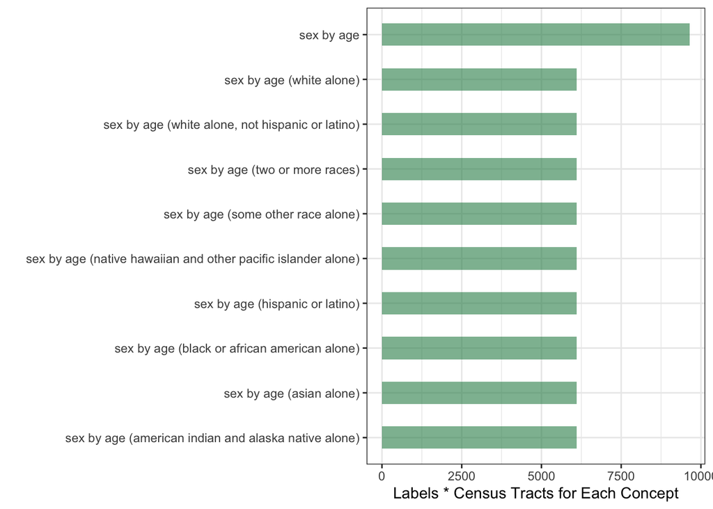

```r
sfpop2019_clean %>%
  # drop un-weildy spatial information
  st_drop_geometry() %>%
  # group by concept column and count labels per concept.
  group_by(concept) %>%
  summarise(n_labels_per_tract = n()) %>%

  # create bar chart of summary object
  mutate(concept = fct_reorder(concept, n_labels_per_tract)) %>%
  ggplot( aes(x=concept, y=n_labels_per_tract)) +
    geom_bar(stat="identity", fill="sea green",
             alpha=.6, width = .5) +
    coord_flip() +
    ylab("Labels * Census Tracts for Each Concept") +
    xlab('') +
  theme_bw()
```

- Sanity Check: mapping subset variables.
- this function should take a minute to resolve due to all the ‘sticky’ spatial stuff in the `geometry` column. It’s unwieldy due to its size, large n of rows.

```r
# use leaflet wrapper for interactive map object.
mapview(sfpop2019_clean, zcol="census_tract",
        legend = F)
```

[output not shown]

Farallon Islands has a census tract, it’s out in the Pacific Ocean. Hover over it to find its designation and remove from API call results.

```r
# filter where census tract is not in Pacific Ocean.
sf2019pop_last <- sfpop2019_clean %>%
  filter(census_tract != 9804.01)
```

Evaluate variable returns with chloropleth map.

```r
# test filter where total male 25-29
sf2019acs_test <- sf2019pop_last %>%
          # alter string based on 'concept' to evaluate
  filter(concept == "sex by age" &
           # alter string based on 'label' to evaluate
           str_detect(label, "total male 25 to 29 years")) %>%
  # restructure estimate from character to numeric structure.
  mutate(estimate = as.numeric(estimate))

# map. hover over shape for estimate of tract population.
mapview(sf2019acs_test, zcol = 'estimate')
```

[interactive chart not shown]

#### Notes:

- When tabbing out dataframes with the `View()` function, there’s a text-based filter tool at the top of the window you can type into and look for labels and concepts of interest.
- Interactive maps are HTML objects and can be finnicky in the markdown window, try copy/pasting code into the R console window and running there to explore in R-studio viewer.
- You can click on the census tract shapes in the map to look at all the data attributes associated with that shape.
- You may also swap ‘moe’ with ‘estimate’ in the `zcol` argument to explore margin of error distributions.